# projekt

Tomek, Krystian

20 pazdziernika 2016

```r
library("caret")
library("party")
library("partykit")
library("rpart")
library("rpart.plot")
library("e1071")
setwd('D:\\RStudio\\projekt')
Dane<-read.csv('GlioblastomaWide.csv', sep=";")

set.seed(12345)
```

Pozbywamy sie zmiennych zawierajacych wiecej niz 30 wartosci “NA” dla pacjetow, ktorzy przezyli lub nie przezyli 1 roku. Pozostaje nam 15780 zmiennych.

```r
Dane$death1y<-as.numeric(ifelse(as.character(Dane$death1y)=='alive',1,0))

duzo_NaN_alive<-(colSums(is.na(Dane[Dane$death1y==1,]))>30)
duzo_NaN_dead<-(colSums(is.na(Dane[Dane$death1y==0,]))>30)
maska<- (duzo_NaN_alive | duzo_NaN_dead)

Dane2<-Dane[,!maska]
```

*ETAP I*

W calu wyboru genow cechujacy sie rozna ekspresja, wykonalismy 10-krotnie test korelacji spearmana (poprawka ‘fdr’, poziom istotnosci 80%) przy czym:

- Najpierw przeprowadzamy test na wszystkich obserwacjach,
- Pozostale 9 na losowo wybranych podzbiorach obserwacji (75% danych, funkcja losowa “createDataPartition”).

Uwzgledniamy geny pojawiajace sie w co najmniej 60% przypadkow.

```r
sumarycznie<-numeric(ncol(Dane2)-4)

kortest<-apply(Dane2[,5:ncol(Dane2)], 2, function(x){cor.test(Dane2[,4],x, method="spearman", na.omit=TRUE, exact=FALSE)$p.value})
names(kortest)<-NULL

log_kortest<-p.adjust(kortest, method="fdr")<0.2

wynik<-log_kortest
sumarycznie<-sumarycznie + wynik

for (i in 1:9){

#Wybieranie próbki testowej
Podzial<-createDataPartition(Dane2$death1y, times=1, p=0.75, list=FALSE)

Dane3 <- Dane2[Podzial,]

kortest<-apply(Dane3[,5:ncol(Dane3)], 2, function(x){cor.test(Dane3[,4],x, method="spearman", na.omit=TRUE, exact=FALSE)$p.value})
names(kortest)<-NULL

log_kortest<-p.adjust(kortest, method="fdr")<0.2

wynik<-log_kortest
sumarycznie<-sumarycznie + wynik
}

y<-which(sumarycznie>=6)+4
```

Oto lista otrzymanych genow:

```r
names(Dane2)[y]
```

```
##  [1] "AQP9"    "CDCP1"   "CLEC5A"  "CPPED1"  "GPNMB"   "IFI44L"  "INSL3"
##  [8] "LILRB3"  "LSP1"    "MLPH"    "MYBPC2"  "PTPRN"   "SLC16A3" "SLC17A9"
## [15] "SLC6A6"  "TBL1XR1" "TM7SF4"  "ZNF569"
```

Boxploty dla pierwszych 6 genow:

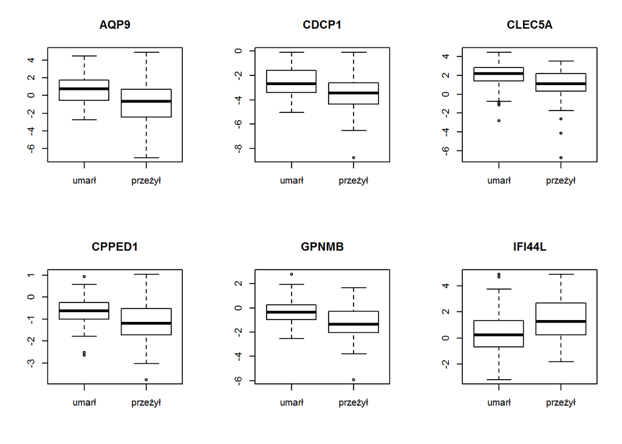

```r
par(mfrow=c(2,3))
for (i in 1:6) {
boxplot(Dane2[,y[i]]~Dane2$death1y, main = names(Dane2)[y[i]], names=c("umarł", "przeżył"))
}
```

*ETAP II*

Testujemy nastepujace klasyfikatory:

- regresja (“NA” zastepujemy mediana)

```r
Danreg=Dane2[,c(4,y)]
mediany<-apply(Danreg, 2, function(x){median(x, na.rm = TRUE)})
for (i in 1:nrow(Danreg)) {
  Danreg[i,-1][is.na(Danreg[i,-1])]<-mediany[is.na(Danreg[i,-1])]
}
regresja <- glm(death1y~., data=Danreg, family="binomial", control = list(maxit = 50))
regresja$coefficients
```

```
## (Intercept)        AQP9       CDCP1      CLEC5A      CPPED1       GPNMB
##  2.38320768  0.01907154 -0.06714590 -0.48112727 -0.11841995 -0.45463452
##      IFI44L       INSL3      LILRB3        LSP1        MLPH      MYBPC2
##  0.46150686 -0.16134703 -0.10582563  0.13879770  0.02405329 -0.21395373
##       PTPRN     SLC16A3     SLC17A9      SLC6A6     TBL1XR1      TM7SF4
## -0.22471278  0.75538050 -0.29320407  0.06546188  3.23594630  0.03474756
##      ZNF569
##  0.92064976
```

- drzewo ctree

```r
Dan=Dane2[,c(4,y)]
Dan$death1y<-as.factor(Dan$death1y)
drzewo <- ctree(death1y~., data=Dan, control=ctree_control(mincriterion = 0.75, testtype="Bonferroni"))
plot(drzewo)
```

[output not shown]

- drzewo rpart

```r
drzewwo <- rpart(death1y~., data=Dan)
rpart.plot(drzewwo)
```

[output not shown]

- naiveBayes

```r
nb <- naiveBayes(death1y ~., data=Dan)
```

Przeprowadzimy testy:

- One-out leave (n-fold cv)
- Repeated k-fold CV
- Tablica kontyngecji dla zwyklego podzialu (“createDataPartition”)
- Tablica kontyngecji dla podzialu bootstrap

*1.* One-out leave (n-fold cv):

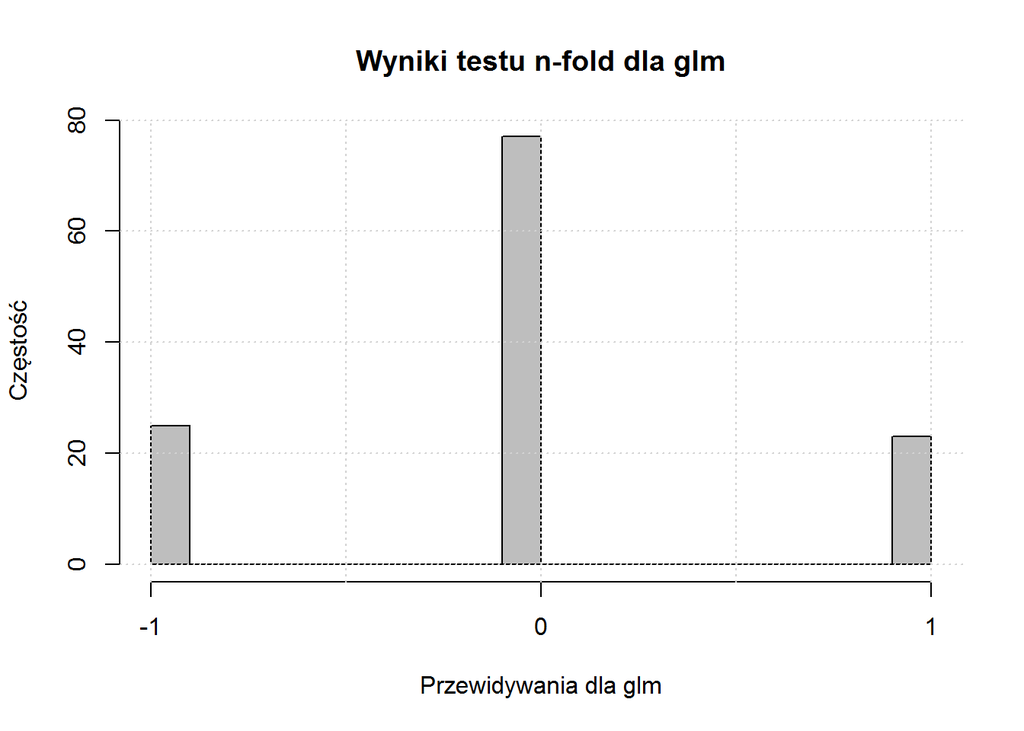

```r
Dane2$death1y<-as.factor(Dane2$death1y)
foldy <- createFolds(Dane2$death1y, k=125)

wyn<-matrix(0,3,4)
colnames(wyn)<-c("glm", "ctree", "rpart", "naiveBayes")
rownames(wyn)<-c("1", "0", "-1")

errors1 <- lapply(foldy, function(ind) {
  model <- glm(death1y~., data=Danreg[-ind,], family = "binomial", control = list(maxit = 50))
predict(model, newdata=Danreg[ind,], "response")- (Danreg[ind,"death1y"] == "1")
})
wyn[1,1]<-length(which(round(unlist(errors1))==1))
wyn[2,1]<-length(which(round(unlist(errors1))==0))
wyn[3,1]<-length(which(round(unlist(errors1))==-1))
hist(round(unlist(errors1)), 20, main=paste("Wyniki testu n-fold dla", colnames(wyn)[1]), xlab = paste("Przewidywania dla", colnames(wyn)[1]), ylab = "Częstość", col="gray", xaxt='n')
axis(side=1, at=-1:1, labels = c(-1,0,1))
grid()
```

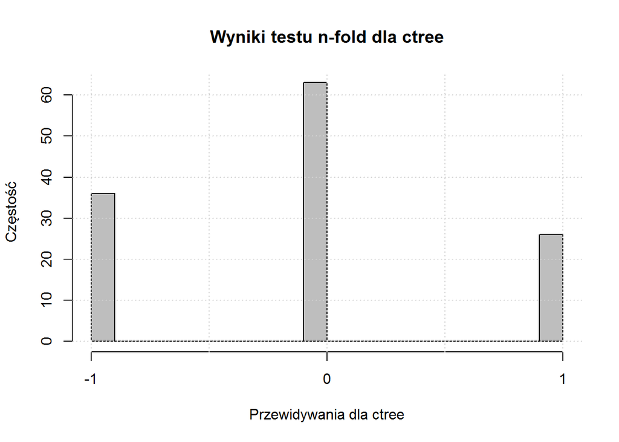

```r
errors2 <- lapply(foldy, function(ind) {
  model <- ctree(death1y~., data=Dane2[-ind,c(4,y)], control=ctree_control(mincriterion = 0.75, testtype="Bonferroni"))
as.numeric(predict(model, newdata=Dane2[ind,]))-as.numeric((Dane2[ind,"death1y"]))
})
wyn[1,2]<-length(which(round(unlist(errors2))==1))
wyn[2,2]<-length(which(round(unlist(errors2))==0))
wyn[3,2]<-length(which(round(unlist(errors2))==-1))
hist(unlist(errors2), 20, main=paste("Wyniki testu n-fold dla", colnames(wyn)[2]), xlab = paste("Przewidywania dla", colnames(wyn)[2]), ylab = "Częstość", col="gray", xaxt='n')
axis(side=1, at=-1:1, labels = c(-1,0,1))
grid()
```

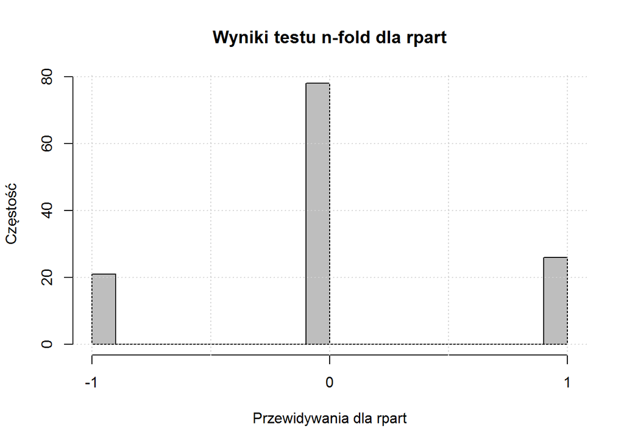

```r
errors3 <- lapply(foldy, function(ind) {
  model <- rpart(death1y~., data=Dane2[-ind,c(4,y)])
as.numeric(predict(model, newdata=Dane2[ind,], type="class"))-as.numeric((Dane2[ind,"death1y"]))
})
wyn[1,3]<-length(which(round(unlist(errors3))==1))
wyn[2,3]<-length(which(round(unlist(errors3))==0))
wyn[3,3]<-length(which(round(unlist(errors3))==-1))
hist(unlist(errors3), 20, main=paste("Wyniki testu n-fold dla", colnames(wyn)[3]), xlab = paste("Przewidywania dla", colnames(wyn)[3]), ylab = "Częstość", col="gray", xaxt='n')
axis(side=1, at=-1:1, labels = c(-1,0,1))
grid()
```

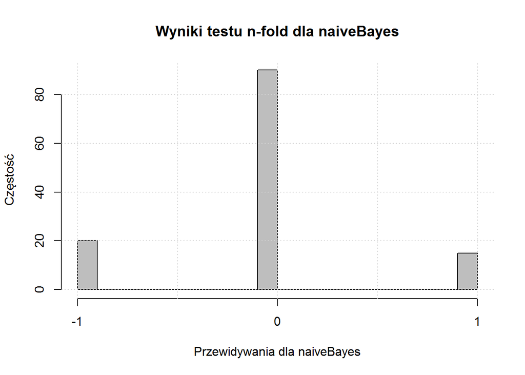

```r
errors4 <- lapply(foldy, function(ind) {
  model <- naiveBayes(death1y~., data=Dane2[-ind,c(4,y)])
  as.numeric(predict(model, newdata=Dane2[ind,]))-as.numeric((Dane2[ind,"death1y"]))
})
wyn[1,4]<-length(which(round(unlist(errors4))==1))
wyn[2,4]<-length(which(round(unlist(errors4))==0))
wyn[3,4]<-length(which(round(unlist(errors4))==-1))
hist(unlist(errors4), 20, main=paste("Wyniki testu n-fold dla", colnames(wyn)[4]), xlab = paste("Przewidywania dla", colnames(wyn)[4]), ylab = "Częstość", col="gray", xaxt='n')
axis(side=1, at=-1:1, labels = c(-1,0,1))
grid()
```

Wynik testu:

```
##    glm ctree rpart naiveBayes
## 1   23    26    26         15
## 0   77    63    78         90
## -1  25    36    21         20
```

*2.* Repeated k-fold CV (5 razy 10-fold)

```r
wynik<-matrix(0,3,4)
colnames(wynik)<-c("glm", "ctree", "rpart", "naiveBayes")
rownames(wynik)<-c("1", "0", "-1")

for(i in 1:5){

foldy <- createFolds(Dane2$death1y, k=10)

errors1 <- lapply(foldy, function(ind) {
  model <- glm(death1y~., data=Danreg[-ind,], family = "binomial")
predict(model, newdata=Danreg[ind,], "response")- (Danreg[ind,"death1y"] == "1")
})
wynik[1,1]<-wynik[1,1]+length(which(round(unlist(errors1))==1))
wynik[2,1]<-wynik[2,1]+length(which(round(unlist(errors1))==0))
wynik[3,1]<-wynik[3,1]+length(which(round(unlist(errors1))==-1))

errors2 <- lapply(foldy, function(ind) {
  model <- ctree(death1y~., data=Dane2[-ind,c(4,y)], control=ctree_control(mincriterion = 0.75, testtype="Bonferroni"))
as.numeric(predict(model, newdata=Dane2[ind,]))-as.numeric((Dane2[ind,"death1y"]))
})
wynik[1,2]<-wynik[1,2]+length(which(round(unlist(errors2))==1))
wynik[2,2]<-wynik[2,2]+length(which(round(unlist(errors2))==0))
wynik[3,2]<-wynik[3,2]+length(which(round(unlist(errors2))==-1))


errors3 <- lapply(foldy, function(ind) {
  model <- rpart(death1y~., data=Dane2[-ind,c(4,y)])
as.numeric(predict(model, newdata=Dane2[ind,], type="class"))-as.numeric((Dane2[ind,"death1y"]))
})
wynik[1,3]<-wynik[1,3]+length(which(round(unlist(errors3))==1))
wynik[2,3]<-wynik[2,3]+length(which(round(unlist(errors3))==0))
wynik[3,3]<-wynik[3,3]+length(which(round(unlist(errors3))==-1))

errors4 <- lapply(foldy, function(ind) {
  model <- naiveBayes(death1y~., data=Dane2[-ind,c(4,y)])
  as.numeric(predict(model, newdata=Dane2[ind,]))-as.numeric((Dane2[ind,"death1y"]))
})
wynik[1,4]<-wynik[1,4]+length(which(round(unlist(errors4))==1))
wynik[2,4]<-wynik[2,4]+length(which(round(unlist(errors4))==0))
wynik[3,4]<-wynik[3,4]+length(which(round(unlist(errors4))==-1))
}
```

Wynik testu:

```
##     glm ctree rpart naiveBayes
## 1  22.4  22.6  25.6       15.8
## 0  79.4  71.2  76.8       89.2
## -1 23.2  31.2  22.6       20.0
```

*3.* Tablica kontyngecji dla zwyklego podzialu (“createDataPartition”)

```r
subset<-createDataPartition(Dane2$death1y, times=1, p=0.75, list=FALSE)
Dan$death1y<-as.factor(Dan$death1y)

cs<-matrix(0,2,4)
colnames(cs)<-c("glm", "ctree", "rpart", "naiveBayes")
rownames(cs)<-c("czulosc", "specyficznosc")


regresja <- glm(death1y~., data=Danreg[subset,], family="binomial", control = list(maxit = 50))
oceny<-predict(regresja, newdata=Danreg[-subset,], type="response") > .5
t<-table(predykcja = oceny, prawdziwe = Danreg[-subset,1])
t
```

```
##          prawdziwe
## predykcja  0  1
##     FALSE 12  9
##     TRUE   3  6
```

```r
cs[1,1]=t[1,1]/(t[1,1]+t[2,1])
cs[2,1]=t[2,2]/(t[2,2]+t[1,2])

drzewo <- ctree(death1y~., data=Dan, control=ctree_control(mincriterion = 0.75, testtype="Bonferroni"))
plot(drzewo)
```

[output not shown]

```r
  oceny <- predict(drzewo, newdata=Dane2[-subset,])
t<-table(predykcja = oceny, prawdziwe = Dane2[-subset,4])
t
```

```
##          prawdziwe
## predykcja  0  1
##         0  7  2
##         1  8 13
```

```r
cs[1,2]=t[1,1]/(t[1,1]+t[2,1])
cs[2,2]=t[2,2]/(t[2,2]+t[1,2])

drzewwo <- rpart(death1y~., data=Dan)
rpart.plot(drzewwo)
```

[output not shown]

```r
oceny<-predict(drzewwo, newdata=Dane2[-subset,], type="class")
t<-table(predykcja = oceny, prawdziwe = Dane2[-subset,4])
t
```

```
##          prawdziwe
## predykcja  0  1
##         0 11  1
##         1  4 14
```

```r
cs[1,3]=t[1,1]/(t[1,1]+t[2,1])
cs[2,3]=t[2,2]/(t[2,2]+t[1,2])

nb <- naiveBayes(death1y ~., data=Dan)
oceny <- predict(nb, newdata=Dane2[-subset,])
t<-table(predykcja = oceny, prawdziwe = Dane2[-subset,4])
t
```

```
##          prawdziwe
## predykcja  0  1
##         0 11  6
##         1  4  9
```

```r
cs[1,4]=t[1,1]/(t[1,1]+t[2,1])
cs[2,4]=t[2,2]/(t[2,2]+t[1,2])
```

Wynik testu - czulosc (% dobrze przewidzanych jako dead) oraz specyficznosc (% dobrze przewidzianych jako alive):

```
##               glm     ctree     rpart naiveBayes
## czulosc       0.8 0.4666667 0.7333333  0.7333333
## specyficznosc 0.4 0.8666667 0.9333333  0.6000000
```

*4.* Tablica kontyngecji dla podzialu bootstrap

```r
subset<-createResample(Dane2$death1y, times = 1, list = FALSE)

cs2<-matrix(0,2,4)
colnames(cs2)<-c("glm", "ctree", "rpart", "naiveBayes")
rownames(cs2)<-c("czulosc", "specyficznosc")


regresja <- glm(death1y~., data=Danreg[subset,], family="binomial", control = list(maxit = 50))
oceny<-predict(regresja, newdata=Danreg[-subset,], type="response") > .5
t<-table(predykcja = oceny, prawdziwe = Danreg[-subset,1])
t
```

```
##          prawdziwe
## predykcja  0  1
##     FALSE 18 12
##     TRUE   4 13
```

```r
cs2[1,1]=t[1,1]/(t[1,1]+t[2,1])
cs2[2,1]=t[2,2]/(t[2,2]+t[1,2])

drzewo <- ctree(death1y~., data=Dan, control=ctree_control(mincriterion = 0.75, testtype="Bonferroni"))
plot(drzewo)
```

[output not shown]

```r
oceny <- predict(drzewo, newdata=Dane2[-subset,])
t<-table(predykcja = oceny, prawdziwe = Dane2[-subset,4])
t
```

```
##          prawdziwe
## predykcja  0  1
##         0 14  7
##         1  8 18
```

```r
cs2[1,2]=t[1,1]/(t[1,1]+t[2,1])
cs2[2,2]=t[2,2]/(t[2,2]+t[1,2])

drzewwo <- rpart(death1y~., data=Dan)
rpart.plot(drzewwo)
```

[output not shown]

```r
oceny<-predict(drzewwo, newdata=Dane2[-subset,], type="class")
t<-table(predykcja = oceny, prawdziwe = Dane2[-subset,4])
t
```

```
##          prawdziwe
## predykcja  0  1
##         0 19  5
##         1  3 20
```

```r
cs2[1,3]=t[1,1]/(t[1,1]+t[2,1])
cs2[2,3]=t[2,2]/(t[2,2]+t[1,2])

nb <- naiveBayes(death1y ~., data=Dan)
oceny <- predict(nb, newdata=Dane2[-subset,])
t<-table(predykcja = oceny, prawdziwe = Dane2[-subset,4])
t
```

```
##          prawdziwe
## predykcja  0  1
##         0 14  8
##         1  8 17
```

```r
cs2[1,4]=t[1,1]/(t[1,1]+t[2,1])
cs2[2,4]=t[2,2]/(t[2,2]+t[1,2])
```

Wynik testu - czulosc (% dobrze przewidzanych jako dead) oraz specyficznosc (% dobrze przewidzianych jako alive):

```
##                     glm     ctree     rpart naiveBayes
## czulosc       0.8181818 0.6363636 0.8636364  0.6363636
## specyficznosc 0.5200000 0.7200000 0.8000000  0.6800000
```